# Titanic Survival

[figure not shown]

## I- Background

The Titanic was a British ocean liner that struck an iceberg and sunk on its maiden voyage in 1912 from the United Kingdom to New York. More than 1,500 of the estimated 2,224 passengers and crew died in the accident, making this one of the largest maritime disasters ever outside of war. The ship carried a wide range of passengers of all ages and both genders, from luxury travelers in first-class to immigrants in the lower classes. However, not all passengers were equally likely to survive the accident. We used real data about a selection of 891 passengers to learn who was on the Titanic and which passengers were more likely to survive.

## II- Demographics of Titanic Passengers

The demographics should give us a big picture of the population on board

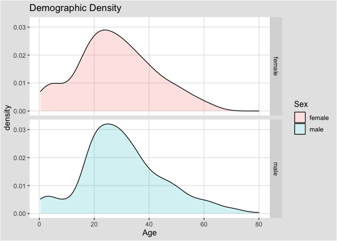

The faceted density plot above shows that each sex has the same general shape with two modes at the same locations, though proportions differ slightly across ages and there are more males than females as confirmed by the stacked count below:

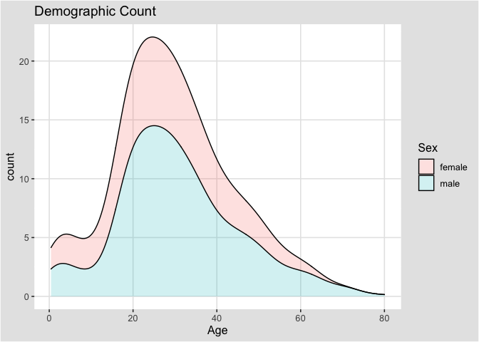

The main mode is around age 25. A second smaller mode is around age 4-5. Obviously, there are more males than females as indicated by a higher total area and higher counts at almost all ages.

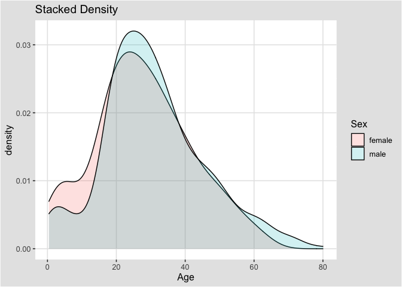

There is a higher proportion of females than males below age 17, a higher proportion of males than females for ages 18-35, approximately the same proportion of males and females age 35-55, and a higher proportion of males over age 55. The oldest individuals are male.

### Demographics conclusion:

- Females and males had the same general shape of age distribution.
- The age distribution was bimodal, with one mode around 25 years of age and a second smaller mode around 5 years of age.
- The count of males of age 40 was higher than the count of females of age 40.
- The proportion of males age 18-35 was higher than the proportion of females age 18-35.
- The proportion of females under age 17 was higher than the proportion of males under age 17.

## II- Survival by Sex

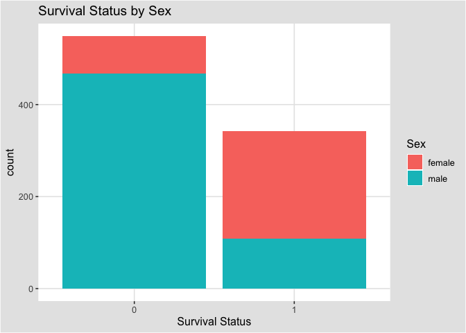

The survival status by sex shows that the count of survivors is lower than the count of non-survivors. The survivor’ bar is mostly female.

It is also clear -above and below that most of the females survived while a majority of males died, in numbers as well as in proportion.

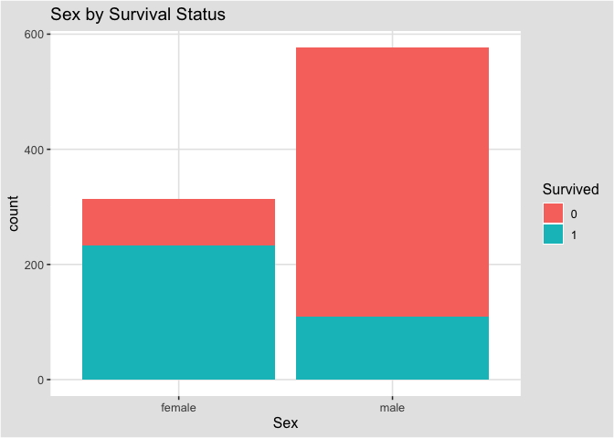

## III- Survival by Age

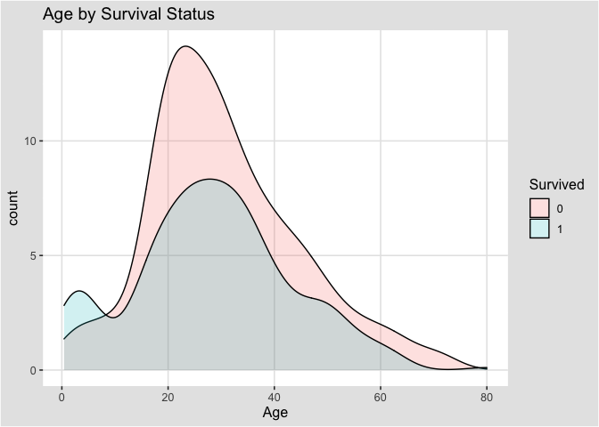

By observing of the density of age by survival status, we can come to the conclusion that: - The age group 0-8 is the only one where it was more likely to survive than die. - The age group 18-30 had the most deaths. - The age group 70-80 had the highest proportion of deaths.

### IV- Survival Status by Fare

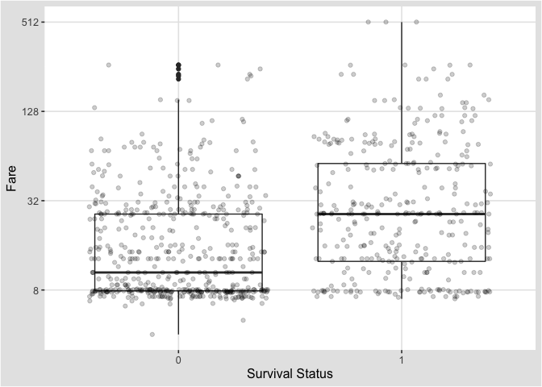

The box plot above proves that: - Passengers who survived generally payed higher fares than those who did not survive. - The median fare was lower for passengers who did not survive. - Most individuals who paid a fare around $8 did not survive.

### IV- Survival Status by Passenger Class

-There were more third class passengers than passengers in the first two classes combined.

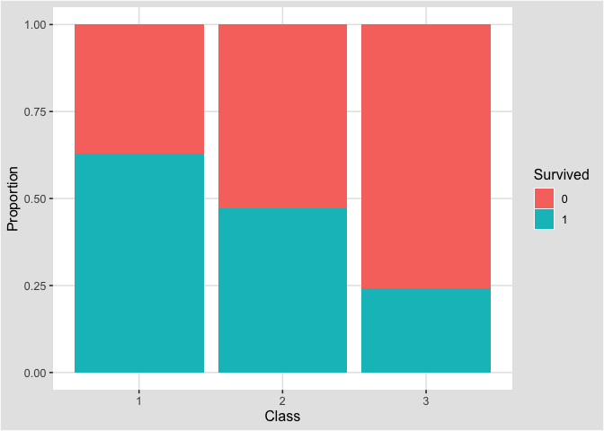

- Survival proportion was highest for first class passengers, followed by second class. Third-class had the lowest survival proportion.
- Most passengers in first class survived. Most passengers in other classes did not survive.

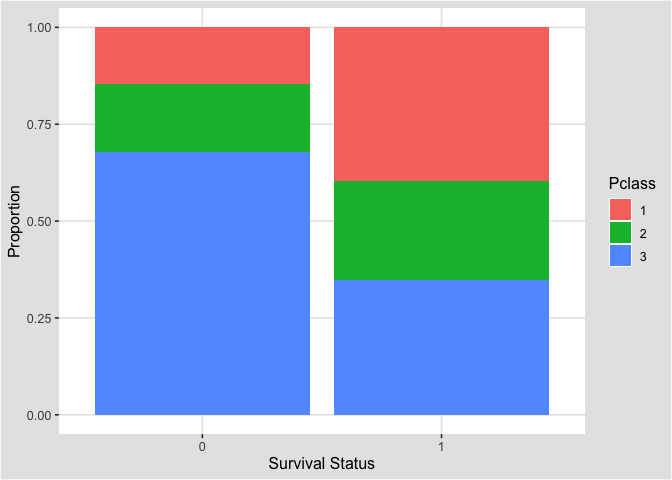

- The majority of those who did not survive were from third class.

### V- Conclusion

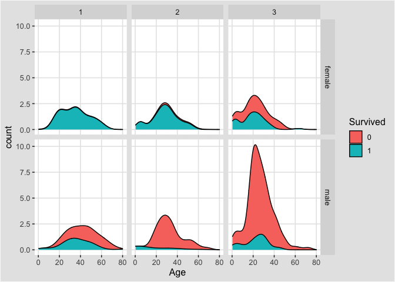

- The largest group of passengers was third-class males.
- Most first-class and second-class females survived.
- Almost all second-class males did not survive, with the exception of children.